# Disfluencies

November 27, 2017

## Introduction

Using the **<disfluencies_2.csv>** data set, we will explore whether the length of a disfluency (measured in ms) is influenced by the following predictors and their interactions:

- SEX (female or male speaker)
- POSITION (of the filler in terms of words)
- GENRE (monologue, dialogue)
- FILLER (type of filler, “uh”, “uhm”, or silence)

### Imports & Initial Data Check

```r
#imports
library("tidyverse"); library("car"); library("effects")
```

```r
dis <- read.delim("disfluencies_2.csv")
knitr::kable(head(dis), caption = "First Five Rows")
```

| CASE | SEX | FILLER | GENRE | LENGTH | POSITION |
| --- | --- | --- | --- | --- | --- |
| 1 | male | uhm | monolog | 1014 | 8 |
| 2 | female | silence | monolog | 1188 | 9 |
| 3 | female | silence | dialog | 889 | 5 |
| 4 | female | uhm | dialog | 265 | 6 |
| 5 | male | uh | dialog | 465 | 10 |
| 6 | female | uh | dialog | 1278 | 8 |

```r
knitr::kable(tail(dis), caption = "Last Five Rows")
```

|  | CASE | SEX | FILLER | GENRE | LENGTH | POSITION |
| --- | --- | --- | --- | --- | --- | --- |
| 995 | 995 | male | uh | dialog | 550 | 6 |
| 996 | 996 | male | silence | dialog | 751 | 10 |
| 997 | 997 | female | uhm | dialog | 1005 | 4 |
| 998 | 998 | female | uhm | monolog | 568 | 2 |
| 999 | 999 | female | uh | dialog | 984 | 8 |
| 1000 | 1000 | female | uh | dialog | 1521 | 11 |

We use the `summary` function to examine the data for any incorrect values that may stick out. Nothing seems amiss.

```r
knitr::kable(summary(dis), caption = "Summary of disfluencies_02.csv")
```

Summary of disfluencies_02.csv

|  | CASE | SEX | FILLER | GENRE | LENGTH | POSITION |
| --- | --- | --- | --- | --- | --- | --- |
|  | Min. : 1.0 | female:502 | silence:332 | dialog :547 | Min. : 251 | Min. : 1.00 |
|  | 1st Qu.: 250.8 | male :498 | uh :394 | monolog:453 | 1st Qu.: 583 | 1st Qu.: 4.00 |
|  | Median : 500.5 |  | uhm :274 |  | Median : 897 | Median : 7.00 |
|  | Mean : 500.5 |  |  |  | Mean : 915 | Mean : 6.57 |
|  | 3rd Qu.: 750.2 |  |  |  | 3rd Qu.:1242 | 3rd Qu.:10.00 |
|  | Max. :1000.0 |  |  |  | Max. :1600 | Max. :12.00 |

Lastly, we also explicitly check for NA’s in the data frame, but there are none.

```r
sum(is.na(dis))
```

```
## [1] 0
```

## Exploratory Data Analysis

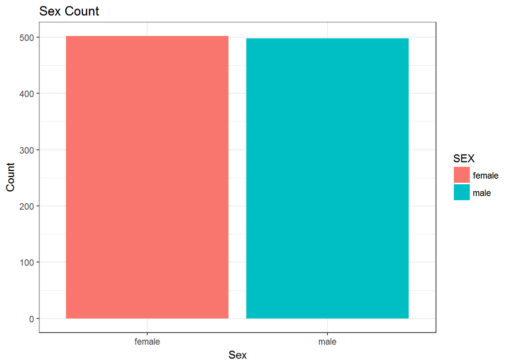

```r
ggplot(dis, aes(SEX, fill = SEX)) +
       theme_bw() +
       geom_bar() +
       labs(title = "Sex Count",
            x = "Sex",
            y = "Count")
```

We see that the number of observations of females and males are about equally well represented in the data.

```r
knitr::kable(prop.table(table(dis$FILLER, dis$SEX), margin = 2), caption = "Disfluencies Used Females to Males")
```

Disfluencies Used Females to Males

|  | female | male |
| --- | --- | --- |
| silence | 0.3406375 | 0.3232932 |
| uh | 0.3207171 | 0.4678715 |
| uhm | 0.3386454 | 0.2088353 |

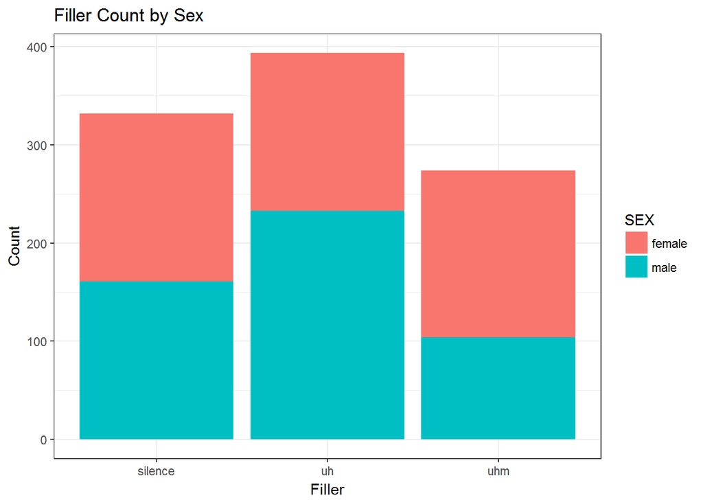

```r
ggplot(dis, aes(x = FILLER, fill = SEX)) +
       theme_bw() +
       geom_bar() +
       labs(title = "Filler Count by Sex",
            x = "Filler",
            y = "Count")
```

We generate a proportion table comparing FILLER by SEX (and graph it), we can see that females used all three fillers equally while males used ‘uh’ almost 50% of the time and dispreferred “uhm”.

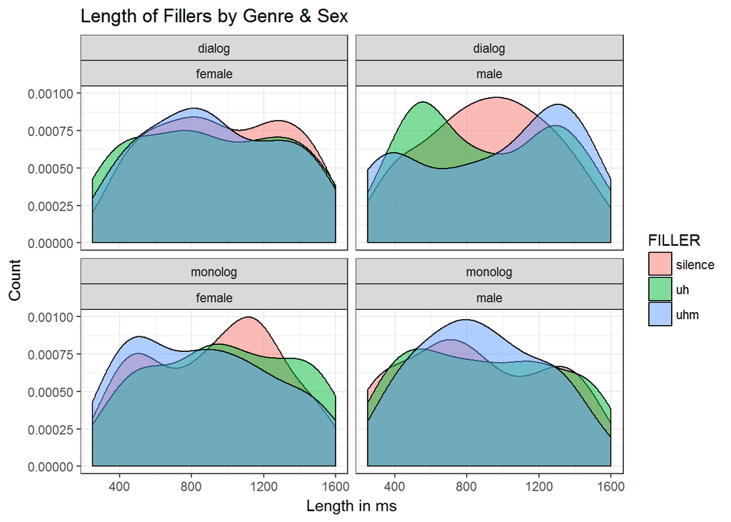

```r
ggplot(data = dis, aes(LENGTH, fill = FILLER))+
       theme_bw() +
       geom_density(alpha = 0.5) +
       facet_wrap(GENRE~SEX) +
       labs(title = "Length of Fillers by Genre & Sex",
            x = "Length in ms",
            y = "Count")
```

When we compare the length of fillers by sex and genre, it appears that in a dialogue, females do not vary length as compared to men, which seem to have 3 have lengths for each filler. During a monologue there doesn’t seem to be a clear differentiation between length.

## Maximal Model

To start modeling, we decided to follow backward selection to generate and summarize a linear maximal model of LENGTH with our four predictors and their three-way interactions.

```r
summary(model.01 <- lm(LENGTH ~ (SEX+POSITION+FILLER+GENRE)^3,
                        data = dis))
```

```
##
## Call:
## lm(formula = LENGTH ~ (SEX + POSITION + FILLER + GENRE)^3, data = dis)
##
## Residuals:
##    Min     1Q Median     3Q    Max
## -708.7 -324.3  -17.3  324.1  792.4
##
## Coefficients:
##                                  Estimate Std. Error t value Pr(>|t|)
## (Intercept)                      932.5748    85.0320  10.967   <2e-16 ***
## SEXmale                          -26.5520   110.3062  -0.241   0.8098
## POSITION                           4.6222    11.1580   0.414   0.6788
## FILLERuh                         -40.9331   117.5526  -0.348   0.7278
## FILLERuhm                        -83.0301   113.3110  -0.733   0.4639
## GENREmonolog                      11.6652   113.4811   0.103   0.9181
## SEXmale:POSITION                  -2.2340    14.1675  -0.158   0.8747
## SEXmale:FILLERuh                  16.1896   139.3728   0.116   0.9075
## SEXmale:FILLERuhm                281.7082   150.5864   1.871   0.0617 .
## SEXmale:GENREmonolog             -16.1146   128.7095  -0.125   0.9004
## POSITION:FILLERuh                 -2.0009    14.6776  -0.136   0.8916
## POSITION:FILLERuhm                 6.1536    14.5244   0.424   0.6719
## POSITION:GENREmonolog             -8.6953    14.6166  -0.595   0.5521
## FILLERuh:GENREmonolog             47.9731   140.3297   0.342   0.7325
## FILLERuhm:GENREmonolog          -178.7165   151.4047  -1.180   0.2381
## SEXmale:POSITION:FILLERuh          3.6251    16.9196   0.214   0.8304
## SEXmale:POSITION:FILLERuhm       -35.2586    18.9846  -1.857   0.0636 .
## SEXmale:POSITION:GENREmonolog     -0.3418    14.5693  -0.023   0.9813
## SEXmale:FILLERuh:GENREmonolog    -52.8113   116.0377  -0.455   0.6491
## SEXmale:FILLERuhm:GENREmonolog    16.0138   129.3556   0.124   0.9015
## POSITION:FILLERuh:GENREmonolog     9.6848    16.8986   0.573   0.5667
## POSITION:FILLERuhm:GENREmonolog   25.9944    18.8182   1.381   0.1675
## ---
## Signif. codes:  0 '***' 0.001 '**' 0.01 '*' 0.05 '.' 0.1 ' ' 1
##
## Residual standard error: 383 on 978 degrees of freedom
## Multiple R-squared:  0.01615,    Adjusted R-squared:  -0.004975
## F-statistic: 0.7645 on 21 and 978 DF,  p-value: 0.7652
```

The initial model does not have a lot of predictive power, the lowest P-values seem to indicate that only a couple interactions (SEXmale:FILLERuhm and SEXmale:FILLERuhm:POSITION) are, dare we say, *‘marginally significant’*. We then call drop1.

```r
drop1(model.01, test = "F")
```

```
## Single term deletions
##
## Model:
## LENGTH ~ (SEX + POSITION + FILLER + GENRE)^3
##                       Df Sum of Sq       RSS   AIC F value  Pr(>F)
## <none>                             143456197 11918
## SEX:POSITION:FILLER    2    748538 144204735 11919  2.5515 0.07848 .
## SEX:POSITION:GENRE     1        81 143456278 11916  0.0006 0.98129
## SEX:FILLER:GENRE       2     52340 143508537 11914  0.1784 0.83663
## POSITION:FILLER:GENRE  2    281967 143738164 11916  0.9611 0.38282
## ---
## Signif. codes:  0 '***' 0.001 '**' 0.01 '*' 0.05 '.' 0.1 ' ' 1
```

As the interaction between SEX:POSITION:GENRE has the highest insignificant p-value, we decide to update our model without it. We view the updated summary and call drop1.

```r
summary(model.02 <- update(model.01, ~. -SEX:POSITION:GENRE))
```

```
##
## Call:
## lm(formula = LENGTH ~ SEX + POSITION + FILLER + GENRE + SEX:POSITION +
##     SEX:FILLER + SEX:GENRE + POSITION:FILLER + POSITION:GENRE +
##     FILLER:GENRE + SEX:POSITION:FILLER + SEX:FILLER:GENRE + POSITION:FILLER:GENRE,
##     data = dis)
##
## Residuals:
##     Min      1Q  Median      3Q     Max
## -708.97 -324.43  -17.57  324.20  791.97
##
## Coefficients:
##                                 Estimate Std. Error t value Pr(>|t|)
## (Intercept)                      932.041     81.889  11.382   <2e-16 ***
## SEXmale                          -25.522    101.139  -0.252   0.8008
## POSITION                           4.702     10.628   0.442   0.6583
## FILLERuh                         -41.052    117.384  -0.350   0.7266
## FILLERuhm                        -82.823    112.908  -0.734   0.4634
## GENREmonolog                      12.822    102.153   0.126   0.9001
## SEXmale:POSITION                  -2.389     12.530  -0.191   0.8488
## SEXmale:FILLERuh                  16.194    139.302   0.116   0.9075
## SEXmale:FILLERuhm                281.718    150.509   1.872   0.0615 .
## SEXmale:GENREmonolog             -18.394     84.371  -0.218   0.8275
## POSITION:FILLERuh                 -1.990     14.663  -0.136   0.8921
## POSITION:FILLERuhm                 6.121     14.451   0.424   0.6720
## POSITION:GENREmonolog             -8.870     12.584  -0.705   0.4811
## FILLERuh:GENREmonolog             48.192    139.946   0.344   0.7306
## FILLERuhm:GENREmonolog          -178.988    150.883  -1.186   0.2358
## SEXmale:POSITION:FILLERuh          3.632     16.908   0.215   0.8300
## SEXmale:POSITION:FILLERuhm       -35.273     18.965  -1.860   0.0632 .
## SEXmale:FILLERuh:GENREmonolog    -52.759    115.957  -0.455   0.6492
## SEXmale:FILLERuhm:GENREmonolog    16.171    129.116   0.125   0.9004
## POSITION:FILLERuh:GENREmonolog     9.650     16.824   0.574   0.5664
## POSITION:FILLERuhm:GENREmonolog   26.037     18.722   1.391   0.1646
## ---
## Signif. codes:  0 '***' 0.001 '**' 0.01 '*' 0.05 '.' 0.1 ' ' 1
##
## Residual standard error: 382.8 on 979 degrees of freedom
## Multiple R-squared:  0.01615,    Adjusted R-squared:  -0.003949
## F-statistic: 0.8035 on 20 and 979 DF,  p-value: 0.7113
```

```r
drop1(model.02, test = "F")
```

```
## Single term deletions
##
## Model:
## LENGTH ~ SEX + POSITION + FILLER + GENRE + SEX:POSITION + SEX:FILLER +
##     SEX:GENRE + POSITION:FILLER + POSITION:GENRE + FILLER:GENRE +
##     SEX:POSITION:FILLER + SEX:FILLER:GENRE + POSITION:FILLER:GENRE
##                       Df Sum of Sq       RSS   AIC F value  Pr(>F)
## <none>                             143456278 11916
## SEX:POSITION:FILLER    2    750983 144207261 11917  2.5625 0.07763 .
## SEX:FILLER:GENRE       2     52424 143508702 11912  0.1789 0.83623
## POSITION:FILLER:GENRE  2    286484 143742761 11914  0.9775 0.37660
## ---
## Signif. codes:  0 '***' 0.001 '**' 0.01 '*' 0.05 '.' 0.1 ' ' 1
```

We decided to remove the interaction between SEX:FILLER:GENRE.

```r
summary(model.03 <- update(model.02, ~. -SEX:FILLER:GENRE))
```

```
##
## Call:
## lm(formula = LENGTH ~ SEX + POSITION + FILLER + GENRE + SEX:POSITION +
##     SEX:FILLER + SEX:GENRE + POSITION:FILLER + POSITION:GENRE +
##     FILLER:GENRE + SEX:POSITION:FILLER + POSITION:FILLER:GENRE,
##     data = dis)
##
## Residuals:
##     Min      1Q  Median      3Q     Max
## -698.99 -321.68  -14.86  322.47  783.03
##
## Coefficients:
##                                 Estimate Std. Error t value Pr(>|t|)
## (Intercept)                      928.217     80.283  11.562   <2e-16 ***
## SEXmale                          -18.000     96.163  -0.187   0.8516
## POSITION                           4.722     10.618   0.445   0.6567
## FILLERuh                         -23.145    111.723  -0.207   0.8359
## FILLERuhm                        -85.744    109.266  -0.785   0.4328
## GENREmonolog                      20.674     96.781   0.214   0.8309
## SEXmale:POSITION                  -2.379     12.520  -0.190   0.8494
## SEXmale:FILLERuh                 -12.143    125.883  -0.096   0.9232
## SEXmale:FILLERuhm                289.962    137.524   2.108   0.0352 *
## SEXmale:GENREmonolog             -34.875     49.759  -0.701   0.4836
## POSITION:FILLERuh                 -2.575     14.615  -0.176   0.8602
## POSITION:FILLERuhm                 6.391     14.417   0.443   0.6577
## POSITION:GENREmonolog             -8.849     12.573  -0.704   0.4817
## FILLERuh:GENREmonolog             18.057    124.910   0.145   0.8851
## FILLERuhm:GENREmonolog          -170.669    137.025  -1.246   0.2132
## SEXmale:POSITION:FILLERuh          4.249     16.862   0.252   0.8011
## SEXmale:POSITION:FILLERuhm       -35.212     18.948  -1.858   0.0634 .
## POSITION:FILLERuh:GENREmonolog     9.750     16.809   0.580   0.5620
## POSITION:FILLERuhm:GENREmonolog   25.483     18.659   1.366   0.1723
## ---
## Signif. codes:  0 '***' 0.001 '**' 0.01 '*' 0.05 '.' 0.1 ' ' 1
##
## Residual standard error: 382.5 on 981 degrees of freedom
## Multiple R-squared:  0.01579,    Adjusted R-squared:  -0.002268
## F-statistic: 0.8744 on 18 and 981 DF,  p-value: 0.6106
```

```r
drop1(model.03, test = "F")
```

```
## Single term deletions
##
## Model:
## LENGTH ~ SEX + POSITION + FILLER + GENRE + SEX:POSITION + SEX:FILLER +
##     SEX:GENRE + POSITION:FILLER + POSITION:GENRE + FILLER:GENRE +
##     SEX:POSITION:FILLER + POSITION:FILLER:GENRE
##                       Df Sum of Sq       RSS   AIC F value Pr(>F)
## <none>                             143508702 11912
## SEX:GENRE              1     71859 143580560 11911  0.4912 0.4836
## SEX:POSITION:FILLER    2    765791 144274492 11914  2.6174 0.0735 .
## POSITION:FILLER:GENRE  2    275202 143783903 11910  0.9406 0.3907
## ---
## Signif. codes:  0 '***' 0.001 '**' 0.01 '*' 0.05 '.' 0.1 ' ' 1
```

We remove POSITION:FILLER:GENRE.

```r
summary(model.04 <- update(model.03, ~. -POSITION:FILLER:GENRE))
```

```
##
## Call:
## lm(formula = LENGTH ~ SEX + POSITION + FILLER + GENRE + SEX:POSITION +
##     SEX:FILLER + SEX:GENRE + POSITION:FILLER + POSITION:GENRE +
##     FILLER:GENRE + SEX:POSITION:FILLER, data = dis)
##
## Residuals:
##     Min      1Q  Median      3Q     Max
## -698.65 -329.48  -14.94  319.25  746.77
##
## Coefficients:
##                             Estimate Std. Error t value Pr(>|t|)
## (Intercept)                 960.7596    73.8470  13.010   <2e-16 ***
## SEXmale                     -17.9097    96.1515  -0.186   0.8523
## POSITION                     -0.2034     9.5149  -0.021   0.9829
## FILLERuh                    -53.6394    99.0528  -0.542   0.5883
## FILLERuhm                  -153.1062    97.1847  -1.575   0.1155
## GENREmonolog                -49.9214    68.6054  -0.728   0.4670
## SEXmale:POSITION             -2.3208    12.5188  -0.185   0.8530
## SEXmale:FILLERuh            -10.5161   125.8535  -0.084   0.9334
## SEXmale:FILLERuhm           271.9323   136.6807   1.990   0.0469 *
## SEXmale:GENREmonolog        -38.1338    49.6982  -0.767   0.4431
## POSITION:FILLERuh             1.9355    12.5597   0.154   0.8776
## POSITION:FILLERuhm           16.4922    12.3254   1.338   0.1812
## POSITION:GENREmonolog         1.9738     7.1391   0.276   0.7822
## FILLERuh:GENREmonolog        83.6260    57.6938   1.449   0.1475
## FILLERuhm:GENREmonolog       -5.1210    63.5694  -0.081   0.9358
## SEXmale:POSITION:FILLERuh     4.1292    16.8605   0.245   0.8066
## SEXmale:POSITION:FILLERuhm  -31.9300    18.7592  -1.702   0.0891 .
## ---
## Signif. codes:  0 '***' 0.001 '**' 0.01 '*' 0.05 '.' 0.1 ' ' 1
##
## Residual standard error: 382.5 on 983 degrees of freedom
## Multiple R-squared:  0.0139, Adjusted R-squared:  -0.002147
## F-statistic: 0.8662 on 16 and 983 DF,  p-value: 0.6091
```

```r
drop1(model.04, test = "F")
```

```
## Single term deletions
##
## Model:
## LENGTH ~ SEX + POSITION + FILLER + GENRE + SEX:POSITION + SEX:FILLER +
##     SEX:GENRE + POSITION:FILLER + POSITION:GENRE + FILLER:GENRE +
##     SEX:POSITION:FILLER
##                     Df Sum of Sq       RSS   AIC F value Pr(>F)
## <none>                           143783903 11910
## SEX:GENRE            1     86118 143870022 11909  0.5888 0.4431
## POSITION:GENRE       1     11181 143795085 11908  0.0764 0.7822
## FILLER:GENRE         2    420555 144204458 11909  1.4376 0.2380
## SEX:POSITION:FILLER  2    653909 144437812 11911  2.2353 0.1075
```

We remove SEX:POSITION:FILLER

```r
summary(model.05 <- update(model.04, ~. -SEX:POSITION:FILLER))
```

```
##
## Call:
## lm(formula = LENGTH ~ SEX + POSITION + FILLER + GENRE + SEX:POSITION +
##     SEX:FILLER + SEX:GENRE + POSITION:FILLER + POSITION:GENRE +
##     FILLER:GENRE, data = dis)
##
## Residuals:
##     Min      1Q  Median      3Q     Max
## -704.46 -327.30  -17.82  322.42  719.08
##
## Coefficients:
##                        Estimate Std. Error t value Pr(>|t|)
## (Intercept)            931.9970    64.6257  14.421   <2e-16 ***
## SEXmale                 29.0629    68.5327   0.424    0.672
## POSITION                 3.9463     7.8595   0.502    0.616
## FILLERuh               -75.9647    75.9570  -1.000    0.318
## FILLERuhm              -64.4607    79.6299  -0.810    0.418
## GENREmonolog           -37.5595    68.4402  -0.549    0.583
## SEXmale:POSITION        -9.1048     7.1977  -1.265    0.206
## SEXmale:FILLERuh        16.4969    57.5723   0.287    0.775
## SEXmale:FILLERuhm       70.2546    64.5648   1.088    0.277
## SEXmale:GENREmonolog   -41.6232    49.6728  -0.838    0.402
## POSITION:FILLERuh        5.0894     8.3864   0.607    0.544
## POSITION:FILLERuhm       3.6658     9.2315   0.397    0.691
## POSITION:GENREmonolog    0.4698     7.1118   0.066    0.947
## FILLERuh:GENREmonolog   85.1842    57.7048   1.476    0.140
## FILLERuhm:GENREmonolog  -9.5482    63.6083  -0.150    0.881
## ---
## Signif. codes:  0 '***' 0.001 '**' 0.01 '*' 0.05 '.' 0.1 ' ' 1
##
## Residual standard error: 382.9 on 985 degrees of freedom
## Multiple R-squared:  0.009419,   Adjusted R-squared:  -0.004661
## F-statistic: 0.669 on 14 and 985 DF,  p-value: 0.8061
```

```r
drop1(model.05, test = "F")
```

```
## Single term deletions
##
## Model:
## LENGTH ~ SEX + POSITION + FILLER + GENRE + SEX:POSITION + SEX:FILLER +
##     SEX:GENRE + POSITION:FILLER + POSITION:GENRE + FILLER:GENRE
##                 Df Sum of Sq       RSS   AIC F value Pr(>F)
## <none>                       144437812 11911
## SEX:POSITION     1    234640 144672452 11910  1.6001 0.2062
## SEX:FILLER       2    183780 144621593 11908  0.6266 0.5346
## SEX:GENRE        1    102962 144540775 11909  0.7022 0.4023
## POSITION:FILLER  2     55763 144493575 11907  0.1901 0.8269
## POSITION:GENRE   1       640 144438452 11909  0.0044 0.9473
## FILLER:GENRE     2    458946 144896759 11910  1.5649 0.2096
```

We removed POSITION:GENRE.

```r
summary(model.06 <- update(model.05, ~. -POSITION:GENRE))
```

```
##
## Call:
## lm(formula = LENGTH ~ SEX + POSITION + FILLER + GENRE + SEX:POSITION +
##     SEX:FILLER + SEX:GENRE + POSITION:FILLER + FILLER:GENRE,
##     data = dis)
##
## Residuals:
##     Min      1Q  Median      3Q     Max
## -705.33 -326.67  -17.79  322.66  718.99
##
## Coefficients:
##                        Estimate Std. Error t value Pr(>|t|)
## (Intercept)             930.628     61.184  15.210   <2e-16 ***
## SEXmale                  28.974     68.485   0.423    0.672
## POSITION                  4.145      7.257   0.571    0.568
## FILLERuh                -75.961     75.919  -1.001    0.317
## FILLERuhm               -64.414     79.586  -0.809    0.419
## GENREmonolog            -34.374     48.542  -0.708    0.479
## SEXmale:POSITION         -9.077      7.182  -1.264    0.207
## SEXmale:FILLERuh         16.537     57.540   0.287    0.774
## SEXmale:FILLERuhm        70.266     64.532   1.089    0.276
## SEXmale:GENREmonolog    -41.738     49.618  -0.841    0.400
## POSITION:FILLERuh         5.077      8.380   0.606    0.545
## POSITION:FILLERuhm        3.662      9.227   0.397    0.692
## FILLERuh:GENREmonolog    85.106     57.664   1.476    0.140
## FILLERuhm:GENREmonolog   -9.677     63.546  -0.152    0.879
## ---
## Signif. codes:  0 '***' 0.001 '**' 0.01 '*' 0.05 '.' 0.1 ' ' 1
##
## Residual standard error: 382.7 on 986 degrees of freedom
## Multiple R-squared:  0.009414,   Adjusted R-squared:  -0.003646
## F-statistic: 0.7208 on 13 and 986 DF,  p-value: 0.7438
```

```r
drop1(model.06, test = "F")
```

```
## Single term deletions
##
## Model:
## LENGTH ~ SEX + POSITION + FILLER + GENRE + SEX:POSITION + SEX:FILLER +
##     SEX:GENRE + POSITION:FILLER + FILLER:GENRE
##                 Df Sum of Sq       RSS   AIC F value Pr(>F)
## <none>                       144438452 11909
## SEX:POSITION     1    234010 144672462 11908  1.5975 0.2066
## SEX:FILLER       2    183783 144622236 11906  0.6273 0.5342
## SEX:GENRE        1    103656 144542108 11907  0.7076 0.4004
## POSITION:FILLER  2     55541 144493993 11905  0.1896 0.8273
## FILLER:GENRE     2    458819 144897271 11908  1.5660 0.2094
```

We remove POSITION:FILLER.

```r
summary(model.07 <- update(model.06, ~. -POSITION:FILLER))
```

```
##
## Call:
## lm(formula = LENGTH ~ SEX + POSITION + FILLER + GENRE + SEX:POSITION +
##     SEX:FILLER + SEX:GENRE + FILLER:GENRE, data = dis)
##
## Residuals:
##     Min      1Q  Median      3Q     Max
## -694.85 -325.04  -17.11  319.57  718.59
##
## Coefficients:
##                        Estimate Std. Error t value Pr(>|t|)
## (Intercept)             911.068     50.436  18.064   <2e-16 ***
## SEXmale                  27.204     67.755   0.402    0.688
## POSITION                  7.103      5.046   1.408    0.160
## FILLERuh                -41.454     49.961  -0.830    0.407
## FILLERuhm               -39.942     49.255  -0.811    0.418
## GENREmonolog            -34.639     48.499  -0.714    0.475
## SEXmale:POSITION         -8.845      7.041  -1.256    0.209
## SEXmale:FILLERuh         16.124     57.486   0.280    0.779
## SEXmale:FILLERuhm        69.890     64.257   1.088    0.277
## SEXmale:GENREmonolog    -41.402     49.569  -0.835    0.404
## FILLERuh:GENREmonolog    83.738     57.534   1.455    0.146
## FILLERuhm:GENREmonolog   -9.696     63.484  -0.153    0.879
## ---
## Signif. codes:  0 '***' 0.001 '**' 0.01 '*' 0.05 '.' 0.1 ' ' 1
##
## Residual standard error: 382.4 on 988 degrees of freedom
## Multiple R-squared:  0.009033,   Adjusted R-squared:  -0.002
## F-statistic: 0.8188 on 11 and 988 DF,  p-value: 0.6213
```

```r
drop1(model.07, test = "F")
```

```
## Single term deletions
##
## Model:
## LENGTH ~ SEX + POSITION + FILLER + GENRE + SEX:POSITION + SEX:FILLER +
##     SEX:GENRE + FILLER:GENRE
##              Df Sum of Sq       RSS   AIC F value Pr(>F)
## <none>                    144493993 11905
## SEX:POSITION  1    230754 144724747 11905  1.5778 0.2094
## SEX:FILLER    2    183943 144677935 11902  0.6289 0.5334
## SEX:GENRE     1    102025 144596018 11904  0.6976 0.4038
## FILLER:GENRE  2    447171 144941164 11904  1.5288 0.2173
```

We remove SEX:FILLER.

```r
summary(model.08 <- update(model.07, ~. -SEX:FILLER))
```

```
##
## Call:
## lm(formula = LENGTH ~ SEX + POSITION + FILLER + GENRE + SEX:POSITION +
##     SEX:GENRE + FILLER:GENRE, data = dis)
##
## Residuals:
##     Min      1Q  Median      3Q     Max
## -689.91 -323.21  -20.74  322.46  708.73
##
## Coefficients:
##                        Estimate Std. Error t value Pr(>|t|)
## (Intercept)             899.946     47.770  18.839   <2e-16 ***
## SEXmale                  52.681     58.114   0.907    0.365
## POSITION                  7.043      5.043   1.397    0.163
## FILLERuh                -34.554     38.854  -0.889    0.374
## FILLERuhm               -14.718     42.738  -0.344    0.731
## GENREmonolog            -35.311     48.476  -0.728    0.467
## SEXmale:POSITION         -9.116      7.035  -1.296    0.195
## SEXmale:GENREmonolog    -39.834     49.529  -0.804    0.421
## FILLERuh:GENREmonolog    83.784     57.494   1.457    0.145
## FILLERuhm:GENREmonolog   -1.427     62.999  -0.023    0.982
## ---
## Signif. codes:  0 '***' 0.001 '**' 0.01 '*' 0.05 '.' 0.1 ' ' 1
##
## Residual standard error: 382.3 on 990 degrees of freedom
## Multiple R-squared:  0.007772,   Adjusted R-squared:  -0.001248
## F-statistic: 0.8616 on 9 and 990 DF,  p-value: 0.5594
```

```r
drop1(model.08, test = "F")
```

```
## Single term deletions
##
## Model:
## LENGTH ~ SEX + POSITION + FILLER + GENRE + SEX:POSITION + SEX:GENRE +
##     FILLER:GENRE
##              Df Sum of Sq       RSS   AIC F value Pr(>F)
## <none>                    144677935 11902
## SEX:POSITION  1    245381 144923317 11902  1.6791 0.1953
## SEX:GENRE     1     94526 144772462 11901  0.6468 0.4214
## FILLER:GENRE  2    410521 145088457 11901  1.4046 0.2460
```

We remove SEX:GENRE.

```r
summary(model.09 <- update(model.08, ~. -SEX:GENRE))
```

```
##
## Call:
## lm(formula = LENGTH ~ SEX + POSITION + FILLER + GENRE + SEX:POSITION +
##     FILLER:GENRE, data = dis)
##
## Residuals:
##     Min      1Q  Median      3Q     Max
## -700.26 -327.22  -21.35  323.97  707.25
##
## Coefficients:
##                        Estimate Std. Error t value Pr(>|t|)
## (Intercept)             910.687     45.857  19.859   <2e-16 ***
## SEXmale                  32.197     52.226   0.616    0.538
## POSITION                  6.793      5.033   1.350    0.177
## FILLERuh                -32.143     38.732  -0.830    0.407
## FILLERuhm               -18.173     42.514  -0.427    0.669
## GENREmonolog            -54.644     42.088  -1.298    0.194
## SEXmale:POSITION         -8.840      7.025  -1.258    0.209
## FILLERuh:GENREmonolog    79.607     57.249   1.391    0.165
## FILLERuhm:GENREmonolog    2.121     62.834   0.034    0.973
## ---
## Signif. codes:  0 '***' 0.001 '**' 0.01 '*' 0.05 '.' 0.1 ' ' 1
##
## Residual standard error: 382.2 on 991 degrees of freedom
## Multiple R-squared:  0.007124,   Adjusted R-squared:  -0.0008915
## F-statistic: 0.8888 on 8 and 991 DF,  p-value: 0.5252
```

```r
drop1(model.09, test = "F")
```

```
## Single term deletions
##
## Model:
## LENGTH ~ SEX + POSITION + FILLER + GENRE + SEX:POSITION + FILLER:GENRE
##              Df Sum of Sq       RSS   AIC F value Pr(>F)
## <none>                    144772462 11901
## SEX:POSITION  1    231297 145003758 11900  1.5833 0.2086
## FILLER:GENRE  2    363890 145136351 11899  1.2455 0.2883
```

We remove FILLER:GENRE.

```r
summary(model.10 <- update(model.09, ~. -FILLER:GENRE))
```

```
##
## Call:
## lm(formula = LENGTH ~ SEX + POSITION + FILLER + GENRE + SEX:POSITION,
##     data = dis)
##
## Residuals:
##     Min      1Q  Median      3Q     Max
## -722.06 -331.06  -17.42  326.60  700.49
##
## Coefficients:
##                  Estimate Std. Error t value Pr(>|t|)
## (Intercept)       898.846     43.280  20.768   <2e-16 ***
## SEXmale            29.496     52.184   0.565    0.572
## POSITION            6.544      5.031   1.301    0.194
## FILLERuh            4.230     28.607   0.148    0.882
## FILLERuhm         -17.138     31.354  -0.547    0.585
## GENREmonolog      -22.754     24.344  -0.935    0.350
## SEXmale:POSITION   -8.805      7.027  -1.253    0.210
## ---
## Signif. codes:  0 '***' 0.001 '**' 0.01 '*' 0.05 '.' 0.1 ' ' 1
##
## Residual standard error: 382.3 on 993 degrees of freedom
## Multiple R-squared:  0.004628,   Adjusted R-squared:  -0.001386
## F-statistic: 0.7695 on 6 and 993 DF,  p-value: 0.594
```

```r
drop1(model.10, test = "F")
```

```
## Single term deletions
##
## Model:
## LENGTH ~ SEX + POSITION + FILLER + GENRE + SEX:POSITION
##              Df Sum of Sq       RSS   AIC F value Pr(>F)
## <none>                    145136351 11899
## FILLER        2     76157 145212508 11896  0.2605 0.7707
## GENRE         1    127694 145264045 11898  0.8737 0.3502
## SEX:POSITION  1    229512 145365863 11899  1.5703 0.2105
```

We remove SEX:POSITION.

```r
summary(model.11 <- update(model.10, ~. -SEX:POSITION))
```

```
##
## Call:
## lm(formula = LENGTH ~ SEX + POSITION + FILLER + GENRE, data = dis)
##
## Residuals:
##     Min      1Q  Median      3Q     Max
## -702.88 -329.33  -14.32  327.82  712.29
##
## Coefficients:
##              Estimate Std. Error t value Pr(>|t|)
## (Intercept)   928.852     36.063  25.757   <2e-16 ***
## SEXmale       -28.190     24.584  -1.147    0.252
## POSITION        2.030      3.513   0.578    0.564
## FILLERuh        4.694     28.613   0.164    0.870
## FILLERuhm     -15.344     31.331  -0.490    0.624
## GENREmonolog  -23.737     24.338  -0.975    0.330
## ---
## Signif. codes:  0 '***' 0.001 '**' 0.01 '*' 0.05 '.' 0.1 ' ' 1
##
## Residual standard error: 382.4 on 994 degrees of freedom
## Multiple R-squared:  0.003054,   Adjusted R-squared:  -0.001961
## F-statistic: 0.609 on 5 and 994 DF,  p-value: 0.6931
```

```r
drop1(model.11, test = "F")
```

```
## Single term deletions
##
## Model:
## LENGTH ~ SEX + POSITION + FILLER + GENRE
##          Df Sum of Sq       RSS   AIC F value Pr(>F)
## <none>                145365863 11899
## SEX       1    192284 145558147 11898  1.3148 0.2518
## POSITION  1     48824 145414687 11897  0.3339 0.5635
## FILLER    2     65821 145431684 11896  0.2250 0.7985
## GENRE     1    139113 145504976 11898  0.9512 0.3296
```

We have removed all interactions and now look at the predictors individually. We drop FILLER.

```r
summary(model.12 <- update(model.11, ~. -FILLER))
```

```
##
## Call:
## lm(formula = LENGTH ~ SEX + POSITION + GENRE, data = dis)
##
## Residuals:
##     Min      1Q  Median      3Q     Max
## -694.71 -328.90  -12.33  332.31  718.17
##
## Coefficients:
##              Estimate Std. Error t value Pr(>|t|)
## (Intercept)   924.846     31.400  29.454   <2e-16 ***
## SEXmale       -25.492     24.200  -1.053    0.292
## POSITION        2.078      3.509   0.592    0.554
## GENREmonolog  -23.759     24.317  -0.977    0.329
## ---
## Signif. codes:  0 '***' 0.001 '**' 0.01 '*' 0.05 '.' 0.1 ' ' 1
##
## Residual standard error: 382.1 on 996 degrees of freedom
## Multiple R-squared:  0.002603,   Adjusted R-squared:  -0.0004016
## F-statistic: 0.8663 on 3 and 996 DF,  p-value: 0.458
```

```r
drop1(model.12, test = "F")
```

```
## Single term deletions
##
## Model:
## LENGTH ~ SEX + POSITION + GENRE
##          Df Sum of Sq       RSS   AIC F value Pr(>F)
## <none>                145431684 11896
## SEX       1    162028 145593711 11895  1.1097 0.2924
## POSITION  1     51210 145482894 11894  0.3507 0.5538
## GENRE     1    139393 145571077 11894  0.9546 0.3288
```

We drop POSITION.

```r
summary(model.13 <- update(model.12, ~. -POSITION))
```

```
##
## Call:
## lm(formula = LENGTH ~ SEX + GENRE, data = dis)
##
## Residuals:
##     Min      1Q  Median      3Q     Max
## -686.13 -328.64  -15.34  330.01  711.45
##
## Coefficients:
##              Estimate Std. Error t value Pr(>|t|)
## (Intercept)    939.13      20.10  46.730   <2e-16 ***
## SEXmale        -26.09      24.17  -1.080    0.281
## GENREmonolog   -24.49      24.28  -1.009    0.313
## ---
## Signif. codes:  0 '***' 0.001 '**' 0.01 '*' 0.05 '.' 0.1 ' ' 1
##
## Residual standard error: 382 on 997 degrees of freedom
## Multiple R-squared:  0.002251,   Adjusted R-squared:  0.0002499
## F-statistic: 1.125 on 2 and 997 DF,  p-value: 0.3251
```

```r
drop1(model.13, test = "F")
```

```
## Single term deletions
##
## Model:
## LENGTH ~ SEX + GENRE
##        Df Sum of Sq       RSS   AIC F value Pr(>F)
## <none>              145482894 11894
## SEX     1    170053 145652947 11893  1.1654 0.2806
## GENRE   1    148476 145631370 11893  1.0175 0.3134
```

We remove GENRE.

```r
summary(model.14 <- update(model.13, ~. -GENRE))
```

```
##
## Call:
## lm(formula = LENGTH ~ SEX, data = dis)
##
## Residuals:
##     Min      1Q  Median      3Q     Max
## -675.40 -327.08  -16.49  326.67  698.42
##
## Coefficients:
##             Estimate Std. Error t value Pr(>|t|)
## (Intercept)   928.40      17.05   54.45   <2e-16 ***
## SEXmale       -26.82      24.16   -1.11    0.267
## ---
## Signif. codes:  0 '***' 0.001 '**' 0.01 '*' 0.05 '.' 0.1 ' ' 1
##
## Residual standard error: 382 on 998 degrees of freedom
## Multiple R-squared:  0.001233,   Adjusted R-squared:  0.0002323
## F-statistic: 1.232 on 1 and 998 DF,  p-value: 0.2673
```

```r
drop1(model.14, test = "F")
```

```
## Single term deletions
##
## Model:
## LENGTH ~ SEX
##        Df Sum of Sq       RSS   AIC F value Pr(>F)
## <none>              145631370 11893
## SEX     1    179800 145811169 11892  1.2322 0.2673
```

Lastly, we remove SEX.

```r
summary(model.15 <- update(model.14, ~. -SEX))
```

```
##
## Call:
## lm(formula = LENGTH ~ 1, data = dis)
##
## Residuals:
##     Min      1Q  Median      3Q     Max
## -664.04 -332.04  -18.04  326.96  684.96
##
## Coefficients:
##             Estimate Std. Error t value Pr(>|t|)
## (Intercept)   915.04      12.08   75.74   <2e-16 ***
## ---
## Signif. codes:  0 '***' 0.001 '**' 0.01 '*' 0.05 '.' 0.1 ' ' 1
##
## Residual standard error: 382 on 999 degrees of freedom
```

```r
drop1(model.15, test = "F")
```

```
## Single term deletions
##
## Model:
## LENGTH ~ 1
##        Df Sum of Sq       RSS   AIC F value Pr(>F)
## <none>              145811169 11892
```

## Conclusion

Having peeled away all the predictors & their interactions, we can conclude that POSITION, SEX, GENRE, and FILLER, nor their three-way interactions are not statistically significant in determining the length of a filler.